# 02_Bartels_Alan_2022

Alan Bartels

2022-09-29

# Part 2

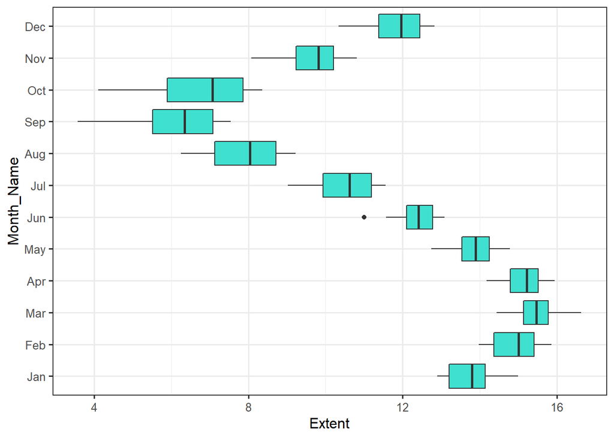

```r
ice_extent <- ggplot(data = ice,
                     mapping = aes(group = Month_Name,
                                   x = Extent,
                                   y = Month_Name))
ice_extent + geom_boxplot(fill = "turquoise")
```

# Part 3

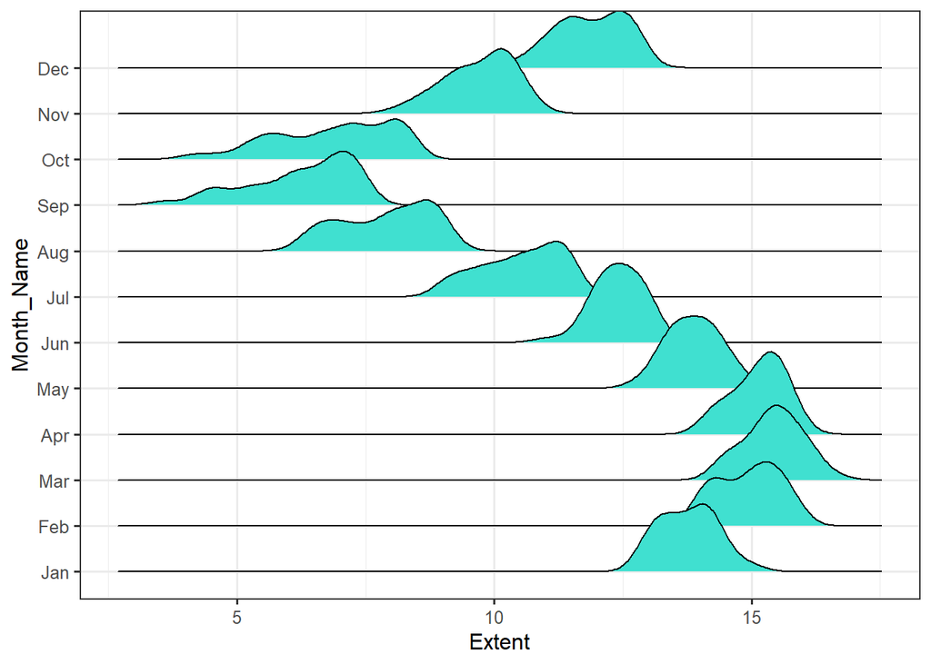

```r
ice_extent + geom_density_ridges(fill = "turquoise")
```

What do you learn that is different than the boxplot?

With ridgelines, one gets a visual of the frequency distribution of the sea ice extent for a given month. For example, February and August do not look dissimilar to other months in their box plot graph. However, in the ridgeline graph, one can see that the distribution of sea ice extent during February and August appear to be bimodal, something that is not apparent in the box plot graph.

# Part 4

Making Groups from the Continuous

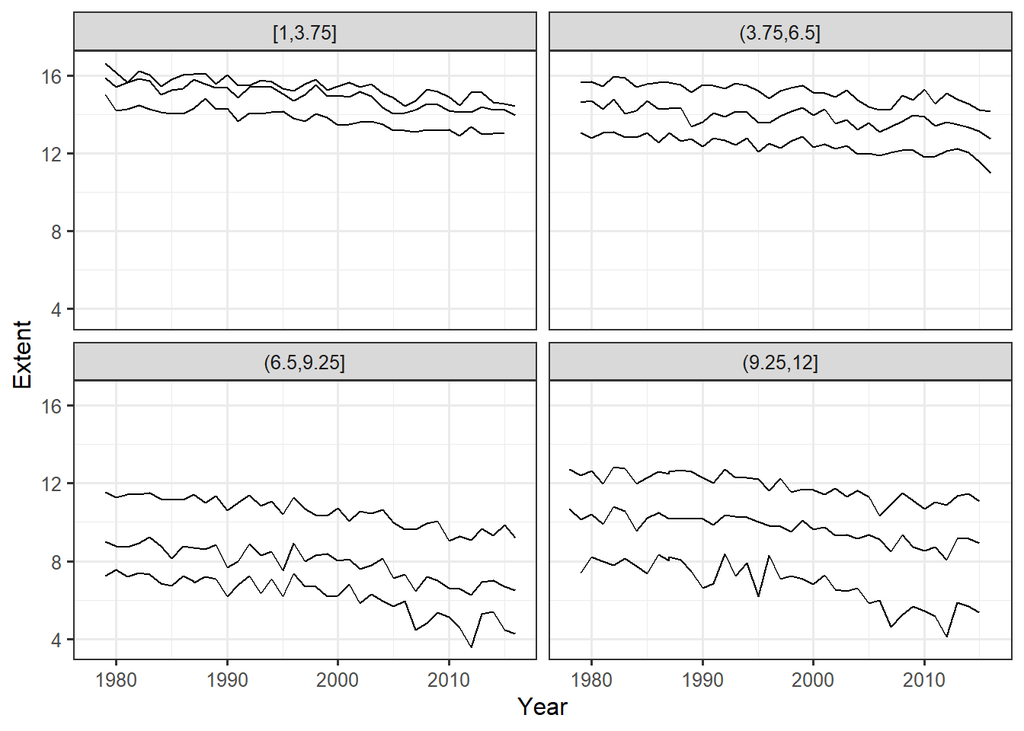

```r
ice_by_month <- ggplot(data = ice,
                       mapping = aes(
                         group = Month_Name,
                         x = Year,
                         y = Extent
                       ))
ice_by_month <- ice_by_month + geom_line()

ice_by_month + facet_wrap(vars(cut_interval(Month, n = 4)))
```

# Part 4

Use that Color!

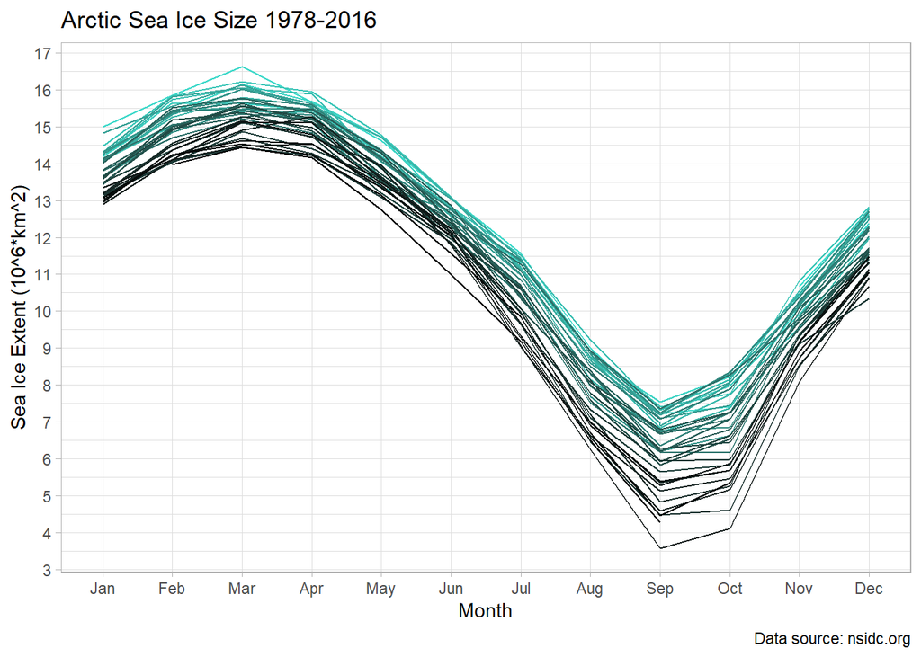

```r
annual_ice_extent <- ggplot(data = ice,
                            mapping = aes(
                              group = Year,
                              x = Month_Name,
                              y = Extent,
                              color = Year
                            ))

annual_ice_graph <- annual_ice_extent +
  geom_line() +
  scale_color_gradient(low = "turquoise", high = "black",
                       limits = c(1978, 2016),
                       guide = "none") +
  labs(title = "Arctic Sea Ice Size 1978-2016",
       x = "Month",
       y = "Sea Ice Extent (10^6*km^2)",
       caption = "Data source: nsidc.org") +
  scale_y_continuous(breaks = 0:20) +
  theme_light()

annual_ice_graph
```

Meta 1. I am definitely more educated on what makes a good graph, scenarios in which to use specific types of graphs etc. However, I am a bit overwhelmed with the number of ggplot tools available and their individual ability to manipulate certain graph features, but their different ways of doing things. I’d like to get to know one tool well, learn all of it’s capabilities, and then add new ones, rather than what I found myself doing which was googling how to do something, and then finding 3 different ways of achieving the goal, each done a new way that might require reorganization of previous code.

Meta 2. What’s your favorite thing about data visualization?

Probably the fact that it matters so much. Data poorly visualized can be impossible to understand. The visualization is the star attraction of a data “story”. The best ones can make results readily apparent, almost obvious, the worst can obfuscate the results entirely.

Meta 3. How much time did this take?

This took me a while longer, about 3hrs.

Meta 4. I give myself a sufficient assessment, I didn’t successfully implement many of the IYKYK or extra credits, but I did learn a lot through my process of failure.